# Risk Factor Analysis

## Outcome Variable

**Outcome Variable:** haz

## Predictor Variables

**Intervention Variable:** predfeed6

**Adjustment Set:**

- arm
- sex
- month
- brthmon
- W_mage
- meducyrs
- feducyrs
- hhwealth_quart
- hfoodsec
- W_mhtcm
- W_mwtkg
- W_mbmi
- vagbrth
- W_gagebrth
- W_birthwt
- W_birthlen
- W_nrooms
- W_nchldlt5
- W_parity
- impfloor
- impsan
- safeh20
- delta_W_mage
- delta_meducyrs
- delta_feducyrs
- delta_hhwealth_quart
- delta_hfoodsec
- delta_W_mhtcm
- delta_W_mwtkg
- delta_W_mbmi
- delta_vagbrth
- delta_W_gagebrth
- delta_W_birthwt
- delta_W_birthlen
- delta_W_nrooms
- delta_W_nchldlt5
- delta_W_parity
- delta_impfloor
- delta_impsan
- delta_safeh20

## Stratifying Variables

The analysis was stratified on these variable(s):

- agecat
- studyid
- country

## Data Summary

| agecat | studyid | country | predfeed6 | n_cell | n |
| --- | --- | --- | --- | --- | --- |
| Birth | ki0047075b-MAL-ED | BANGLADESH | 1 | 72 | 205 |
| Birth | ki0047075b-MAL-ED | BANGLADESH | 0 | 133 | 205 |
| Birth | ki0047075b-MAL-ED | BRAZIL | 1 | 6 | 60 |
| Birth | ki0047075b-MAL-ED | BRAZIL | 0 | 54 | 60 |
| Birth | ki0047075b-MAL-ED | INDIA | 1 | 4 | 39 |
| Birth | ki0047075b-MAL-ED | INDIA | 0 | 35 | 39 |
| Birth | ki0047075b-MAL-ED | NEPAL | 1 | 3 | 24 |
| Birth | ki0047075b-MAL-ED | NEPAL | 0 | 21 | 24 |
| Birth | ki0047075b-MAL-ED | PERU | 1 | 73 | 213 |
| Birth | ki0047075b-MAL-ED | PERU | 0 | 140 | 213 |
| Birth | ki0047075b-MAL-ED | SOUTH AFRICA | 1 | 1 | 91 |
| Birth | ki0047075b-MAL-ED | SOUTH AFRICA | 0 | 90 | 91 |
| Birth | ki0047075b-MAL-ED | TANZANIA, UNITED REPUBLIC OF | 1 | 0 | 113 |
| Birth | ki0047075b-MAL-ED | TANZANIA, UNITED REPUBLIC OF | 0 | 113 | 113 |
| Birth | ki1000109-EE | PAKISTAN | 1 | 38 | 42 |
| Birth | ki1000109-EE | PAKISTAN | 0 | 4 | 42 |
| Birth | ki1113344-GMS-Nepal | NEPAL | 1 | 419 | 563 |
| Birth | ki1113344-GMS-Nepal | NEPAL | 0 | 144 | 563 |
| Birth | kiGH5241-JiVitA-3 | BANGLADESH | 1 | 12323 | 15793 |
| Birth | kiGH5241-JiVitA-3 | BANGLADESH | 0 | 3470 | 15793 |
| Birth | kiGH5241-JiVitA-4 | BANGLADESH | 1 | 2103 | 2632 |
| Birth | kiGH5241-JiVitA-4 | BANGLADESH | 0 | 529 | 2632 |
| 6 months | ki0047075b-MAL-ED | BANGLADESH | 1 | 84 | 231 |
| 6 months | ki0047075b-MAL-ED | BANGLADESH | 0 | 147 | 231 |
| 6 months | ki0047075b-MAL-ED | BRAZIL | 1 | 30 | 209 |
| 6 months | ki0047075b-MAL-ED | BRAZIL | 0 | 179 | 209 |
| 6 months | ki0047075b-MAL-ED | INDIA | 1 | 11 | 218 |
| 6 months | ki0047075b-MAL-ED | INDIA | 0 | 207 | 218 |
| 6 months | ki0047075b-MAL-ED | NEPAL | 1 | 12 | 225 |
| 6 months | ki0047075b-MAL-ED | NEPAL | 0 | 213 | 225 |
| 6 months | ki0047075b-MAL-ED | PERU | 1 | 92 | 271 |
| 6 months | ki0047075b-MAL-ED | PERU | 0 | 179 | 271 |
| 6 months | ki0047075b-MAL-ED | SOUTH AFRICA | 1 | 3 | 233 |
| 6 months | ki0047075b-MAL-ED | SOUTH AFRICA | 0 | 230 | 233 |
| 6 months | ki0047075b-MAL-ED | TANZANIA, UNITED REPUBLIC OF | 1 | 1 | 232 |
| 6 months | ki0047075b-MAL-ED | TANZANIA, UNITED REPUBLIC OF | 0 | 231 | 232 |
| 6 months | ki1000109-EE | PAKISTAN | 1 | 43 | 48 |
| 6 months | ki1000109-EE | PAKISTAN | 0 | 5 | 48 |
| 6 months | ki1000304b-SAS-FoodSuppl | INDIA | 1 | 0 | 168 |
| 6 months | ki1000304b-SAS-FoodSuppl | INDIA | 0 | 168 | 168 |
| 6 months | ki1113344-GMS-Nepal | NEPAL | 1 | 406 | 547 |
| 6 months | ki1113344-GMS-Nepal | NEPAL | 0 | 141 | 547 |
| 6 months | ki1148112-LCNI-5 | MALAWI | 1 | 47 | 272 |
| 6 months | ki1148112-LCNI-5 | MALAWI | 0 | 225 | 272 |
| 6 months | kiGH5241-JiVitA-3 | BANGLADESH | 1 | 7624 | 9877 |
| 6 months | kiGH5241-JiVitA-3 | BANGLADESH | 0 | 2253 | 9877 |
| 6 months | kiGH5241-JiVitA-4 | BANGLADESH | 1 | 3328 | 4272 |
| 6 months | kiGH5241-JiVitA-4 | BANGLADESH | 0 | 944 | 4272 |
| 24 months | ki0047075b-MAL-ED | BANGLADESH | 1 | 76 | 205 |
| 24 months | ki0047075b-MAL-ED | BANGLADESH | 0 | 129 | 205 |
| 24 months | ki0047075b-MAL-ED | BRAZIL | 1 | 25 | 169 |
| 24 months | ki0047075b-MAL-ED | BRAZIL | 0 | 144 | 169 |
| 24 months | ki0047075b-MAL-ED | INDIA | 1 | 11 | 209 |
| 24 months | ki0047075b-MAL-ED | INDIA | 0 | 198 | 209 |
| 24 months | ki0047075b-MAL-ED | NEPAL | 1 | 12 | 219 |
| 24 months | ki0047075b-MAL-ED | NEPAL | 0 | 207 | 219 |
| 24 months | ki0047075b-MAL-ED | PERU | 1 | 68 | 201 |
| 24 months | ki0047075b-MAL-ED | PERU | 0 | 133 | 201 |
| 24 months | ki0047075b-MAL-ED | SOUTH AFRICA | 1 | 3 | 216 |
| 24 months | ki0047075b-MAL-ED | SOUTH AFRICA | 0 | 213 | 216 |
| 24 months | ki0047075b-MAL-ED | TANZANIA, UNITED REPUBLIC OF | 1 | 1 | 202 |
| 24 months | ki0047075b-MAL-ED | TANZANIA, UNITED REPUBLIC OF | 0 | 201 | 202 |
| 24 months | ki1000109-EE | PAKISTAN | 1 | 20 | 23 |
| 24 months | ki1000109-EE | PAKISTAN | 0 | 3 | 23 |
| 24 months | ki1113344-GMS-Nepal | NEPAL | 1 | 356 | 470 |
| 24 months | ki1113344-GMS-Nepal | NEPAL | 0 | 114 | 470 |
| 24 months | ki1148112-LCNI-5 | MALAWI | 1 | 34 | 189 |
| 24 months | ki1148112-LCNI-5 | MALAWI | 0 | 155 | 189 |
| 24 months | kiGH5241-JiVitA-3 | BANGLADESH | 1 | 3897 | 5048 |
| 24 months | kiGH5241-JiVitA-3 | BANGLADESH | 0 | 1151 | 5048 |
| 24 months | kiGH5241-JiVitA-4 | BANGLADESH | 1 | 3292 | 4199 |
| 24 months | kiGH5241-JiVitA-4 | BANGLADESH | 0 | 907 | 4199 |

The following strata were considered:

- agecat: 24 months, studyid: ki0047075b-MAL-ED, country: BANGLADESH
- agecat: 24 months, studyid: ki0047075b-MAL-ED, country: BRAZIL
- agecat: 24 months, studyid: ki0047075b-MAL-ED, country: INDIA
- agecat: 24 months, studyid: ki0047075b-MAL-ED, country: NEPAL
- agecat: 24 months, studyid: ki0047075b-MAL-ED, country: PERU
- agecat: 24 months, studyid: ki0047075b-MAL-ED, country: SOUTH AFRICA
- agecat: 24 months, studyid: ki0047075b-MAL-ED, country: TANZANIA, UNITED REPUBLIC OF
- agecat: 24 months, studyid: ki1000109-EE, country: PAKISTAN
- agecat: 24 months, studyid: ki1113344-GMS-Nepal, country: NEPAL
- agecat: 24 months, studyid: ki1148112-LCNI-5, country: MALAWI
- agecat: 24 months, studyid: kiGH5241-JiVitA-3, country: BANGLADESH
- agecat: 24 months, studyid: kiGH5241-JiVitA-4, country: BANGLADESH
- agecat: 6 months, studyid: ki0047075b-MAL-ED, country: BANGLADESH
- agecat: 6 months, studyid: ki0047075b-MAL-ED, country: BRAZIL
- agecat: 6 months, studyid: ki0047075b-MAL-ED, country: INDIA
- agecat: 6 months, studyid: ki0047075b-MAL-ED, country: NEPAL
- agecat: 6 months, studyid: ki0047075b-MAL-ED, country: PERU
- agecat: 6 months, studyid: ki0047075b-MAL-ED, country: SOUTH AFRICA
- agecat: 6 months, studyid: ki0047075b-MAL-ED, country: TANZANIA, UNITED REPUBLIC OF
- agecat: 6 months, studyid: ki1000109-EE, country: PAKISTAN
- agecat: 6 months, studyid: ki1000304b-SAS-FoodSuppl, country: INDIA
- agecat: 6 months, studyid: ki1113344-GMS-Nepal, country: NEPAL
- agecat: 6 months, studyid: ki1148112-LCNI-5, country: MALAWI
- agecat: 6 months, studyid: kiGH5241-JiVitA-3, country: BANGLADESH
- agecat: 6 months, studyid: kiGH5241-JiVitA-4, country: BANGLADESH
- agecat: Birth, studyid: ki0047075b-MAL-ED, country: BANGLADESH
- agecat: Birth, studyid: ki0047075b-MAL-ED, country: BRAZIL
- agecat: Birth, studyid: ki0047075b-MAL-ED, country: INDIA
- agecat: Birth, studyid: ki0047075b-MAL-ED, country: NEPAL
- agecat: Birth, studyid: ki0047075b-MAL-ED, country: PERU
- agecat: Birth, studyid: ki0047075b-MAL-ED, country: SOUTH AFRICA
- agecat: Birth, studyid: ki0047075b-MAL-ED, country: TANZANIA, UNITED REPUBLIC OF
- agecat: Birth, studyid: ki1000109-EE, country: PAKISTAN
- agecat: Birth, studyid: ki1113344-GMS-Nepal, country: NEPAL
- agecat: Birth, studyid: kiGH5241-JiVitA-3, country: BANGLADESH
- agecat: Birth, studyid: kiGH5241-JiVitA-4, country: BANGLADESH

### Dropped Strata

Some strata were dropped due to rare outcomes:

- agecat: Birth, studyid: ki0047075b-MAL-ED, country: INDIA
- agecat: Birth, studyid: ki0047075b-MAL-ED, country: NEPAL
- agecat: Birth, studyid: ki0047075b-MAL-ED, country: SOUTH AFRICA
- agecat: Birth, studyid: ki0047075b-MAL-ED, country: TANZANIA, UNITED REPUBLIC OF
- agecat: Birth, studyid: ki1000109-EE, country: PAKISTAN
- agecat: 6 months, studyid: ki0047075b-MAL-ED, country: SOUTH AFRICA
- agecat: 6 months, studyid: ki0047075b-MAL-ED, country: TANZANIA, UNITED REPUBLIC OF
- agecat: 6 months, studyid: ki1000304b-SAS-FoodSuppl, country: INDIA
- agecat: 24 months, studyid: ki0047075b-MAL-ED, country: SOUTH AFRICA
- agecat: 24 months, studyid: ki0047075b-MAL-ED, country: TANZANIA, UNITED REPUBLIC OF
- agecat: 24 months, studyid: ki1000109-EE, country: PAKISTAN

## Methods Detail

We’re interested in the causal parameters $E[Y_a]$ for all values of $a \in \mathcal{A}$. These parameters represent the mean outcome if, possibly contrary to fact, we intervened to set all units to have $A=a$. Under the randomization and positivity assumptions, these are identified by the statistical parameters $\psi_a=E_W[E_{Y|A,W}(Y|A=a,W)]$. In addition, we’re interested in the mean of $Y$, $E[Y]$ under no intervention (the observed mean). We will estimate these parameters by using SuperLearner to fit the relevant likelihood factors – $E_{Y|A,W}(Y|A=a,W)$ and $p(A=a|W)$, and then updating our likelihood fit using a joint TMLE.

For unadjusted analyses ($W=\{\}$), initial likelihoods were estimated using Lrnr_glm to estimate the simple $E(Y|A)$ and Lrnr_mean to estimate $p(A)$. For adjusted analyses, a small library containing Lrnr_glmnet, Lrnr_xgboost, and Lrnr_mean was used.

Having estimated these parameters, we will then use the delta method to estimate relative risks and attributable risks relative to a prespecified baseline level of $A$.

# Results Detail

## Results Plots

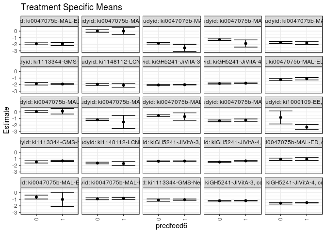

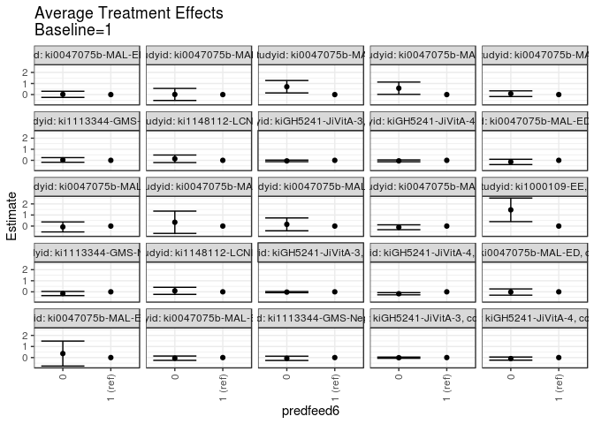

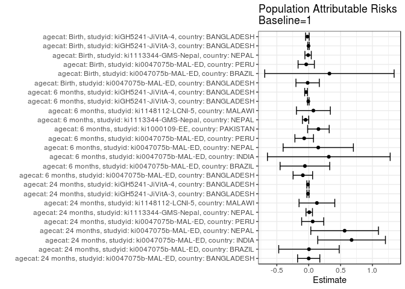

## Results Table

### Parameter: TSM

| agecat | studyid | country | intervention_level | baseline_level | estimate | ci_lower | ci_upper |
| --- | --- | --- | --- | --- | --- | --- | --- |
| Birth | ki0047075b-MAL-ED | BANGLADESH | 1 | NA | -1.0363916 | -1.2553751 | -0.8174081 |
| Birth | ki0047075b-MAL-ED | BANGLADESH | 0 | NA | -1.0569491 | -1.2334404 | -0.8804577 |
| Birth | ki0047075b-MAL-ED | BRAZIL | 1 | NA | -1.0216667 | -2.1085384 | 0.0652051 |
| Birth | ki0047075b-MAL-ED | BRAZIL | 0 | NA | -0.6601852 | -0.9595686 | -0.3608018 |
| Birth | ki0047075b-MAL-ED | PERU | 1 | NA | -0.8677955 | -1.0330071 | -0.7025839 |
| Birth | ki0047075b-MAL-ED | PERU | 0 | NA | -0.9234756 | -1.0717248 | -0.7752264 |
| Birth | ki1113344-GMS-Nepal | NEPAL | 1 | NA | -1.0548175 | -1.1521681 | -0.9574669 |
| Birth | ki1113344-GMS-Nepal | NEPAL | 0 | NA | -1.1228182 | -1.2979299 | -0.9477065 |
| Birth | kiGH5241-JiVitA-3 | BANGLADESH | 1 | NA | -1.2128791 | -1.2467664 | -1.1789919 |
| Birth | kiGH5241-JiVitA-3 | BANGLADESH | 0 | NA | -1.2251534 | -1.2789211 | -1.1713857 |
| Birth | kiGH5241-JiVitA-4 | BANGLADESH | 1 | NA | -1.5067098 | -1.5590367 | -1.4543830 |
| Birth | kiGH5241-JiVitA-4 | BANGLADESH | 0 | NA | -1.5999612 | -1.7322859 | -1.4676364 |
| 6 months | ki0047075b-MAL-ED | BANGLADESH | 1 | NA | -1.0987859 | -1.2812757 | -0.9162962 |
| 6 months | ki0047075b-MAL-ED | BANGLADESH | 0 | NA | -1.2415552 | -1.3971456 | -1.0859649 |
| 6 months | ki0047075b-MAL-ED | BRAZIL | 1 | NA | 0.1104762 | -0.3176181 | 0.5385706 |
| 6 months | ki0047075b-MAL-ED | BRAZIL | 0 | NA | 0.0335821 | -0.1165791 | 0.1837432 |
| 6 months | ki0047075b-MAL-ED | INDIA | 1 | NA | -1.5341830 | -2.5319564 | -0.5364095 |
| 6 months | ki0047075b-MAL-ED | INDIA | 0 | NA | -1.1890520 | -1.3101709 | -1.0679330 |
| 6 months | ki0047075b-MAL-ED | NEPAL | 1 | NA | -0.7117394 | -1.2781111 | -0.1453676 |
| 6 months | ki0047075b-MAL-ED | NEPAL | 0 | NA | -0.5570507 | -0.6754479 | -0.4386535 |
| 6 months | ki0047075b-MAL-ED | PERU | 1 | NA | -1.2559079 | -1.4338272 | -1.0779887 |
| 6 months | ki0047075b-MAL-ED | PERU | 0 | NA | -1.3623083 | -1.4970158 | -1.2276009 |
| 6 months | ki1000109-EE | PAKISTAN | 1 | NA | -2.3121318 | -2.6865239 | -1.9377397 |
| 6 months | ki1000109-EE | PAKISTAN | 0 | NA | -0.8473333 | -1.8424880 | 0.1478213 |
| 6 months | ki1113344-GMS-Nepal | NEPAL | 1 | NA | -1.3054951 | -1.3943226 | -1.2166677 |
| 6 months | ki1113344-GMS-Nepal | NEPAL | 0 | NA | -1.4585646 | -1.6276530 | -1.2894761 |
| 6 months | ki1148112-LCNI-5 | MALAWI | 1 | NA | -1.7133444 | -2.0064455 | -1.4202433 |
| 6 months | ki1148112-LCNI-5 | MALAWI | 0 | NA | -1.6254731 | -1.7568024 | -1.4941437 |
| 6 months | kiGH5241-JiVitA-3 | BANGLADESH | 1 | NA | -1.3311627 | -1.3616194 | -1.3007059 |
| 6 months | kiGH5241-JiVitA-3 | BANGLADESH | 0 | NA | -1.3561191 | -1.4054865 | -1.3067517 |
| 6 months | kiGH5241-JiVitA-4 | BANGLADESH | 1 | NA | -1.3072961 | -1.3484456 | -1.2661467 |
| 6 months | kiGH5241-JiVitA-4 | BANGLADESH | 0 | NA | -1.4806663 | -1.5718912 | -1.3894415 |
| 24 months | ki0047075b-MAL-ED | BANGLADESH | 1 | NA | -1.9583922 | -2.1908698 | -1.7259145 |
| 24 months | ki0047075b-MAL-ED | BANGLADESH | 0 | NA | -1.9344542 | -2.0869530 | -1.7819555 |
| 24 months | ki0047075b-MAL-ED | BRAZIL | 1 | NA | 0.0027446 | -0.5058311 | 0.5113203 |
| 24 months | ki0047075b-MAL-ED | BRAZIL | 0 | NA | 0.0146379 | -0.1725317 | 0.2018074 |
| 24 months | ki0047075b-MAL-ED | INDIA | 1 | NA | -2.5576905 | -3.1029509 | -2.0124301 |
| 24 months | ki0047075b-MAL-ED | INDIA | 0 | NA | -1.8475126 | -1.9789626 | -1.7160626 |
| 24 months | ki0047075b-MAL-ED | NEPAL | 1 | NA | -1.8869552 | -2.4298017 | -1.3441087 |
| 24 months | ki0047075b-MAL-ED | NEPAL | 0 | NA | -1.3118636 | -1.4375394 | -1.1861879 |
| 24 months | ki0047075b-MAL-ED | PERU | 1 | NA | -1.8171217 | -2.0259332 | -1.6083102 |
| 24 months | ki0047075b-MAL-ED | PERU | 0 | NA | -1.7363171 | -1.8891015 | -1.5835327 |
| 24 months | ki1113344-GMS-Nepal | NEPAL | 1 | NA | -1.9085388 | -2.0033379 | -1.8137396 |
| 24 months | ki1113344-GMS-Nepal | NEPAL | 0 | NA | -1.8726867 | -2.0639590 | -1.6814145 |
| 24 months | ki1148112-LCNI-5 | MALAWI | 1 | NA | -2.0941453 | -2.3940851 | -1.7942055 |
| 24 months | ki1148112-LCNI-5 | MALAWI | 0 | NA | -1.9545016 | -2.1129963 | -1.7960070 |
| 24 months | kiGH5241-JiVitA-3 | BANGLADESH | 1 | NA | -2.0062527 | -2.0459012 | -1.9666042 |
| 24 months | kiGH5241-JiVitA-3 | BANGLADESH | 0 | NA | -2.0562136 | -2.1229785 | -1.9894488 |
| 24 months | kiGH5241-JiVitA-4 | BANGLADESH | 1 | NA | -1.7796192 | -1.8214632 | -1.7377752 |
| 24 months | kiGH5241-JiVitA-4 | BANGLADESH | 0 | NA | -1.8271819 | -1.9029656 | -1.7513982 |

### Parameter: E(Y)

| agecat | studyid | country | intervention_level | baseline_level | estimate | ci_lower | ci_upper |
| --- | --- | --- | --- | --- | --- | --- | --- |
| Birth | ki0047075b-MAL-ED | BANGLADESH | NA | NA | -1.0530244 | -1.1913751 | -0.9146736 |
| Birth | ki0047075b-MAL-ED | BRAZIL | NA | NA | -0.6963333 | -0.9881882 | -0.4044785 |
| Birth | ki0047075b-MAL-ED | PERU | NA | NA | -0.9065728 | -1.0297267 | -0.7834188 |
| Birth | ki1113344-GMS-Nepal | NEPAL | NA | NA | -1.0641208 | -1.1525364 | -0.9757052 |
| Birth | kiGH5241-JiVitA-3 | BANGLADESH | NA | NA | -1.2156259 | -1.2478377 | -1.1834141 |
| Birth | kiGH5241-JiVitA-4 | BANGLADESH | NA | NA | -1.5273138 | -1.5765339 | -1.4780937 |
| 6 months | ki0047075b-MAL-ED | BANGLADESH | NA | NA | -1.1905988 | -1.3103463 | -1.0708514 |
| 6 months | ki0047075b-MAL-ED | BRAZIL | NA | NA | 0.0510207 | -0.0930194 | 0.1950608 |
| 6 months | ki0047075b-MAL-ED | INDIA | NA | NA | -1.2185703 | -1.3422027 | -1.0949380 |
| 6 months | ki0047075b-MAL-ED | NEPAL | NA | NA | -0.5616889 | -0.6770008 | -0.4463770 |
| 6 months | ki0047075b-MAL-ED | PERU | NA | NA | -1.3264945 | -1.4355111 | -1.2174779 |
| 6 months | ki1000109-EE | PAKISTAN | NA | NA | -2.1595486 | -2.5331781 | -1.7859192 |
| 6 months | ki1113344-GMS-Nepal | NEPAL | NA | NA | -1.3540280 | -1.4334801 | -1.2745760 |
| 6 months | ki1148112-LCNI-5 | MALAWI | NA | NA | -1.6395956 | -1.7592633 | -1.5199278 |
| 6 months | kiGH5241-JiVitA-3 | BANGLADESH | NA | NA | -1.3370052 | -1.3650190 | -1.3089913 |
| 6 months | kiGH5241-JiVitA-4 | BANGLADESH | NA | NA | -1.3482303 | -1.3866421 | -1.3098185 |
| 24 months | ki0047075b-MAL-ED | BANGLADESH | NA | NA | -1.9581707 | -2.0862906 | -1.8300508 |
| 24 months | ki0047075b-MAL-ED | BRAZIL | NA | NA | 0.0071006 | -0.1615817 | 0.1757828 |
| 24 months | ki0047075b-MAL-ED | INDIA | NA | NA | -1.8848804 | -2.0154334 | -1.7543274 |
| 24 months | ki0047075b-MAL-ED | NEPAL | NA | NA | -1.3232192 | -1.4452887 | -1.2011496 |
| 24 months | ki0047075b-MAL-ED | PERU | NA | NA | -1.7544776 | -1.8753255 | -1.6336298 |
| 24 months | ki1113344-GMS-Nepal | NEPAL | NA | NA | -1.9002128 | -1.9869255 | -1.8135001 |
| 24 months | ki1148112-LCNI-5 | MALAWI | NA | NA | -1.9651323 | -2.1053230 | -1.8249415 |
| 24 months | kiGH5241-JiVitA-3 | BANGLADESH | NA | NA | -2.0173019 | -2.0536076 | -1.9809962 |
| 24 months | kiGH5241-JiVitA-4 | BANGLADESH | NA | NA | -1.7914765 | -1.8297816 | -1.7531715 |

### Parameter: ATE

| agecat | studyid | country | intervention_level | baseline_level | estimate | ci_lower | ci_upper |
| --- | --- | --- | --- | --- | --- | --- | --- |
| Birth | ki0047075b-MAL-ED | BANGLADESH | 1 | 1 | 0.0000000 | 0.0000000 | 0.0000000 |
| Birth | ki0047075b-MAL-ED | BANGLADESH | 0 | 1 | -0.0205574 | -0.3025352 | 0.2614203 |
| Birth | ki0047075b-MAL-ED | BRAZIL | 1 | 1 | 0.0000000 | 0.0000000 | 0.0000000 |
| Birth | ki0047075b-MAL-ED | BRAZIL | 0 | 1 | 0.3614815 | -0.7658697 | 1.4888326 |
| Birth | ki0047075b-MAL-ED | PERU | 1 | 1 | 0.0000000 | 0.0000000 | 0.0000000 |
| Birth | ki0047075b-MAL-ED | PERU | 0 | 1 | -0.0556801 | -0.2496742 | 0.1383140 |
| Birth | ki1113344-GMS-Nepal | NEPAL | 1 | 1 | 0.0000000 | 0.0000000 | 0.0000000 |
| Birth | ki1113344-GMS-Nepal | NEPAL | 0 | 1 | -0.0680007 | -0.2613502 | 0.1253488 |
| Birth | kiGH5241-JiVitA-3 | BANGLADESH | 1 | 1 | 0.0000000 | 0.0000000 | 0.0000000 |
| Birth | kiGH5241-JiVitA-3 | BANGLADESH | 0 | 1 | -0.0122743 | -0.0659540 | 0.0414054 |
| Birth | kiGH5241-JiVitA-4 | BANGLADESH | 1 | 1 | 0.0000000 | 0.0000000 | 0.0000000 |
| Birth | kiGH5241-JiVitA-4 | BANGLADESH | 0 | 1 | -0.0932513 | -0.2346607 | 0.0481580 |
| 6 months | ki0047075b-MAL-ED | BANGLADESH | 1 | 1 | 0.0000000 | 0.0000000 | 0.0000000 |
| 6 months | ki0047075b-MAL-ED | BANGLADESH | 0 | 1 | -0.1427693 | -0.3830656 | 0.0975270 |
| 6 months | ki0047075b-MAL-ED | BRAZIL | 1 | 1 | 0.0000000 | 0.0000000 | 0.0000000 |
| 6 months | ki0047075b-MAL-ED | BRAZIL | 0 | 1 | -0.0768942 | -0.5303287 | 0.3765403 |
| 6 months | ki0047075b-MAL-ED | INDIA | 1 | 1 | 0.0000000 | 0.0000000 | 0.0000000 |
| 6 months | ki0047075b-MAL-ED | INDIA | 0 | 1 | 0.3451310 | -0.6600448 | 1.3503069 |
| 6 months | ki0047075b-MAL-ED | NEPAL | 1 | 1 | 0.0000000 | 0.0000000 | 0.0000000 |
| 6 months | ki0047075b-MAL-ED | NEPAL | 0 | 1 | 0.1546887 | -0.4243334 | 0.7337108 |
| 6 months | ki0047075b-MAL-ED | PERU | 1 | 1 | 0.0000000 | 0.0000000 | 0.0000000 |
| 6 months | ki0047075b-MAL-ED | PERU | 0 | 1 | -0.1064004 | -0.3258617 | 0.1130608 |
| 6 months | ki1000109-EE | PAKISTAN | 1 | 1 | 0.0000000 | 0.0000000 | 0.0000000 |
| 6 months | ki1000109-EE | PAKISTAN | 0 | 1 | 1.4647984 | 0.4015477 | 2.5280492 |
| 6 months | ki1113344-GMS-Nepal | NEPAL | 1 | 1 | 0.0000000 | 0.0000000 | 0.0000000 |
| 6 months | ki1113344-GMS-Nepal | NEPAL | 0 | 1 | -0.1530694 | -0.3434810 | 0.0373421 |
| 6 months | ki1148112-LCNI-5 | MALAWI | 1 | 1 | 0.0000000 | 0.0000000 | 0.0000000 |
| 6 months | ki1148112-LCNI-5 | MALAWI | 0 | 1 | 0.0878713 | -0.2308312 | 0.4065738 |
| 6 months | kiGH5241-JiVitA-3 | BANGLADESH | 1 | 1 | 0.0000000 | 0.0000000 | 0.0000000 |
| 6 months | kiGH5241-JiVitA-3 | BANGLADESH | 0 | 1 | -0.0249564 | -0.0775226 | 0.0276097 |
| 6 months | kiGH5241-JiVitA-4 | BANGLADESH | 1 | 1 | 0.0000000 | 0.0000000 | 0.0000000 |
| 6 months | kiGH5241-JiVitA-4 | BANGLADESH | 0 | 1 | -0.1733702 | -0.2720504 | -0.0746901 |
| 24 months | ki0047075b-MAL-ED | BANGLADESH | 1 | 1 | 0.0000000 | 0.0000000 | 0.0000000 |
| 24 months | ki0047075b-MAL-ED | BANGLADESH | 0 | 1 | 0.0239379 | -0.2543386 | 0.3022145 |
| 24 months | ki0047075b-MAL-ED | BRAZIL | 1 | 1 | 0.0000000 | 0.0000000 | 0.0000000 |
| 24 months | ki0047075b-MAL-ED | BRAZIL | 0 | 1 | 0.0118933 | -0.5316490 | 0.5554355 |
| 24 months | ki0047075b-MAL-ED | INDIA | 1 | 1 | 0.0000000 | 0.0000000 | 0.0000000 |
| 24 months | ki0047075b-MAL-ED | INDIA | 0 | 1 | 0.7101779 | 0.1491073 | 1.2712485 |
| 24 months | ki0047075b-MAL-ED | NEPAL | 1 | 1 | 0.0000000 | 0.0000000 | 0.0000000 |
| 24 months | ki0047075b-MAL-ED | NEPAL | 0 | 1 | 0.5750916 | 0.0184221 | 1.1317610 |
| 24 months | ki0047075b-MAL-ED | PERU | 1 | 1 | 0.0000000 | 0.0000000 | 0.0000000 |
| 24 months | ki0047075b-MAL-ED | PERU | 0 | 1 | 0.0808046 | -0.1766540 | 0.3382633 |
| 24 months | ki1113344-GMS-Nepal | NEPAL | 1 | 1 | 0.0000000 | 0.0000000 | 0.0000000 |
| 24 months | ki1113344-GMS-Nepal | NEPAL | 0 | 1 | 0.0358520 | -0.1749304 | 0.2466344 |
| 24 months | ki1148112-LCNI-5 | MALAWI | 1 | 1 | 0.0000000 | 0.0000000 | 0.0000000 |
| 24 months | ki1148112-LCNI-5 | MALAWI | 0 | 1 | 0.1396437 | -0.2002230 | 0.4795104 |
| 24 months | kiGH5241-JiVitA-3 | BANGLADESH | 1 | 1 | 0.0000000 | 0.0000000 | 0.0000000 |
| 24 months | kiGH5241-JiVitA-3 | BANGLADESH | 0 | 1 | -0.0499609 | -0.1220643 | 0.0221425 |
| 24 months | kiGH5241-JiVitA-4 | BANGLADESH | 1 | 1 | 0.0000000 | 0.0000000 | 0.0000000 |
| 24 months | kiGH5241-JiVitA-4 | BANGLADESH | 0 | 1 | -0.0475627 | -0.1296326 | 0.0345073 |

### Parameter: PAR

| agecat | studyid | country | intervention_level | baseline_level | estimate | ci_lower | ci_upper |
| --- | --- | --- | --- | --- | --- | --- | --- |
| Birth | ki0047075b-MAL-ED | BANGLADESH | 1 | NA | -0.0166328 | -0.2001189 | 0.1668533 |
| Birth | ki0047075b-MAL-ED | BRAZIL | 1 | NA | 0.3253333 | -0.6896600 | 1.3403266 |
| Birth | ki0047075b-MAL-ED | PERU | 1 | NA | -0.0387773 | -0.1665551 | 0.0890006 |
| Birth | ki1113344-GMS-Nepal | NEPAL | 1 | NA | -0.0093033 | -0.0592150 | 0.0406085 |
| Birth | kiGH5241-JiVitA-3 | BANGLADESH | 1 | NA | -0.0027468 | -0.0145213 | 0.0090277 |
| Birth | kiGH5241-JiVitA-4 | BANGLADESH | 1 | NA | -0.0206040 | -0.0490530 | 0.0078450 |
| 6 months | ki0047075b-MAL-ED | BANGLADESH | 1 | NA | -0.0918129 | -0.2448898 | 0.0612640 |
| 6 months | ki0047075b-MAL-ED | BRAZIL | 1 | NA | -0.0594555 | -0.4488293 | 0.3299183 |
| 6 months | ki0047075b-MAL-ED | INDIA | 1 | NA | 0.3156126 | -0.6470473 | 1.2782726 |
| 6 months | ki0047075b-MAL-ED | NEPAL | 1 | NA | 0.1500505 | -0.4011422 | 0.7012432 |
| 6 months | ki0047075b-MAL-ED | PERU | 1 | NA | -0.0705866 | -0.2162900 | 0.0751169 |
| 6 months | ki1000109-EE | PAKISTAN | 1 | NA | 0.1525832 | -0.0166253 | 0.3217916 |
| 6 months | ki1113344-GMS-Nepal | NEPAL | 1 | NA | -0.0485329 | -0.0978640 | 0.0007982 |
| 6 months | ki1148112-LCNI-5 | MALAWI | 1 | NA | 0.0737488 | -0.1922115 | 0.3397091 |
| 6 months | kiGH5241-JiVitA-3 | BANGLADESH | 1 | NA | -0.0058425 | -0.0178127 | 0.0061277 |
| 6 months | kiGH5241-JiVitA-4 | BANGLADESH | 1 | NA | -0.0409342 | -0.0626122 | -0.0192562 |
| 24 months | ki0047075b-MAL-ED | BANGLADESH | 1 | NA | 0.0002214 | -0.1741988 | 0.1746417 |
| 24 months | ki0047075b-MAL-ED | BRAZIL | 1 | NA | 0.0043560 | -0.4701828 | 0.4788947 |
| 24 months | ki0047075b-MAL-ED | INDIA | 1 | NA | 0.6728101 | 0.1418721 | 1.2037481 |
| 24 months | ki0047075b-MAL-ED | NEPAL | 1 | NA | 0.5637360 | 0.0332390 | 1.0942330 |
| 24 months | ki0047075b-MAL-ED | PERU | 1 | NA | 0.0626441 | -0.1103739 | 0.2356621 |
| 24 months | ki1113344-GMS-Nepal | NEPAL | 1 | NA | 0.0083260 | -0.0425581 | 0.0592100 |
| 24 months | ki1148112-LCNI-5 | MALAWI | 1 | NA | 0.1290130 | -0.1512561 | 0.4092821 |
| 24 months | kiGH5241-JiVitA-3 | BANGLADESH | 1 | NA | -0.0110492 | -0.0275110 | 0.0054127 |
| 24 months | kiGH5241-JiVitA-4 | BANGLADESH | 1 | NA | -0.0118573 | -0.0294851 | 0.0057705 |